# Review of the current state of PMDD scientific literature in Pubmed

Ana Ramos

# Introduction

# Data input

The data used in this analysis was all obtained from PubMed using the command line Entrez tools. The data was obtained in an XML file, which was then converted to JSON using yq, and then loaded onto a local database using [DuckDB](https://duckdb.org/docs/api/r) (`pmdd.db`).

This notebook will use a combination of `DuckDB` and `tidyverse` packages to process the data. Let’s first establish a connection to the `pmdd.db` database with the data imported from PubMed using `pmdd_entrez.sh`.Once connected to the database, let’s load the “entrez_clean” table into a dataframe. Since we will not need to load any more data from the database in this notebook, we will now close the connection to `pmdd.db`.

```r
# Set working directory
knitr::opts_knit$set(root.dir = '~/Documents/Projects/pmdd/pmdd_pubmed')
```

# Analysis and visualization

With the data loaded we can start exploring it by further querying and building visualizations. Before jumping into the data, let’s first frame some of the questions I would like to answer in this notebook.

## How many PMDD articles were published in PubMed each year?

We will use the publication date, represented by the `pub_date` field in the `entrez_clean` table just added to our database.

```r
# Install packges
library(duckdb)
library(tidyverse)
library(forcats)
library(conflicted)

# Connect to DuckDB database
database_path <- file.path("data", "pmdd.db")

con <- dbConnect(duckdb(), dbdir = database_path)
#on.exit(dbDisconnect(con), add = TRUE)

# or
#con <- dbConnect(duckdb(), dbdir = ":memory:")

# Get table from database and store in dataframe
entrez_clean <- dbGetQuery(con, "SELECT * FROM entrez_clean;")

# Close connection to database
dbDisconnect(con, shutdown=TRUE)
```

Out of the 1,352 PMDD publications in PubMed until the end of July 2024, only ~42% provide an accepted date (date when the publication was accepted by the publisher). For the publications missing this field, we can pull the “PubDate” field from Entrez, which corresponds to the date when the article became available in the journal. Therefore, we can create a new field, `publication_year`, which will use the year from the accepted_date, and the year from PubDate for the records where the accepted_date is not available. By doing so, we get 99% coverage.

Now that we understand the data a bit better, let’s calculate the number of publications produced each year using the `publication_year` field. This calculation is stored in the `n_articles_year` dataframe.

```r
entrez_clean %>%
  summarize(with_dates = n_distinct(case_when(is.na(accepted_date) == FALSE  ~ pubmed_id)),
            without_dates = n_distinct(case_when(is.na(accepted_date) ~ pubmed_id)),
            with_pubication_year = n_distinct(case_when(is.na(publication_year) == FALSE  ~ pubmed_id)),
            all = n_distinct(pubmed_id)
            )
```

| with_dates | without_dates | with_pubication_year | all |
| --- | --- | --- | --- |
| 564 | 790 | 1349 | 1352 |

Looking at the number of studies focused on PMDD that have been published over the years, we can see that the field started to gain traction by the end of the 80s. Coincidentally,diagnosis criteria for late luteal phase dysphoric disorder (LLPDD) was included in the DSM-III in 1987 (Endicott, 2000). The name premenstrual dysphoric disorder (PMDD) was coined in the DSM-IV in 1993 after the diagnostic criterion and newer evidence were further analyzed. However, at this point PMDD was included under the “Conditions for further study” diagnostic class. It wasn’t until 2013, in the DSM-5 edition that PMDD was included under the “depressive disorder” diagnostic class.

Through all this time PMDD was still only recognized as a psychological condition, and it remained excluded from the International Classification of Diseases, a standardized description of diseases and physiological conditions published by the WHO. In 2019, the ICD-11 edition finally included PMDD as a physiological condition.

It is likely that having proper diagnosis criteria and a validation of PMDD as both a psychological and physiological condition encouraged scientists to explore this condition further, which could explain the increasing number of publications per year up until the early 2000s and the second spike in publications from 2020 onward. Between the years 2000 and 2020, an average of 43 ± 6 publications were published per year. However, after 2020 there was a new spike in publications per year, reaching 79 and 87 publications in 2022 and 2023, respectively.

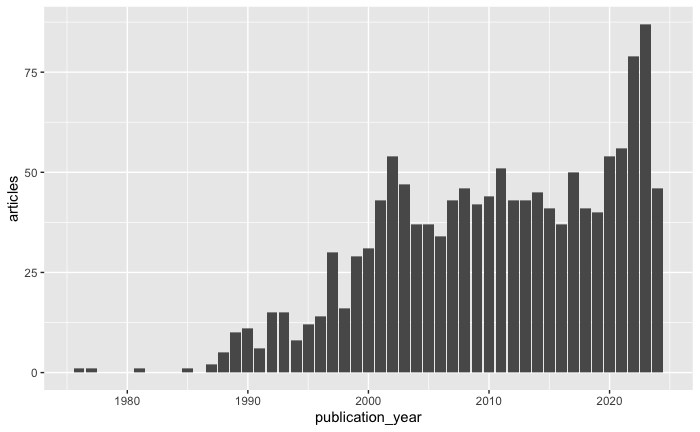

```r
## Get number of publications per year
n_articles_year <- entrez_clean |>
  group_by(publication_year) |>
  summarize(articles = n_distinct(pubmed_id))

## Let's plot the publications per year
ggplot(data = filter(n_articles_year, !is.na(publication_year))) +
  geom_col(mapping = aes(x = publication_year, y = articles))
```